# Comparison of Classical Machine Learning Models for Colorectal Cancer Microbiome Classification

Harshini Chintala

2026-09-04

## 0.1 Notebook roadmap

**Purpose:** This notebook is one reproducible component of the CRC microbiome classification pipeline.

**Execution order** 1. Load the project environment and fixed random seed (`1910`). 2. Load only the validated project artifacts required for this analysis. 3. Perform the analysis exactly as documented below. 4. Generate tables/figures and save machine-readable outputs. 5. Record the session information used for the run.

**Output contract:** generated tables, figures, model objects, audit files, and session information are written under `02 Classical ML/results/`. The notebook itself renders to HTML with a floating table of contents, so the sections can be navigated from the left-hand panel in the knitted document.

**Reproducibility rule:** this repository preserves the validated analysis logic and project-wide seed. Environment restoration is handled by `renv.lock` for R and `requirements.txt` for Python. The notebooks do not silently install unpinned packages during knitting.

### 0.1.1 Reproducibility constants

- Project seed: **1910**
- Discovery cohort: **ZellerG_2014**
- Primary task: **Healthy vs CRC; adenoma excluded**
- Frozen discovery split: **92 training / 22 held-out test samples**
- Primary feature panel: **20 Boruta-selected features**
- External cohorts: **FengQ_2015** and **VogtmannE_2016**

# 1 Load Packages

```r
library(tidyverse)
library(knitr)
library(ggplot2)
library(scales)
library(viridis)
library(reshape2)
library(stringr)
library(purrr)
library(dplyr)
library(tibble)
library(here)
```

# 2 Global Theme

```r
theme_set(
theme_bw(base_size = 13)+
theme(
plot.title = element_text(face="bold",size=16),
plot.subtitle = element_text(size=12),
axis.title = element_text(face="bold"),
legend.position="bottom",
panel.grid.minor=element_blank()
)
)
```

# 3 Read Results Workbook

```r
# The original workbook is retained in the repository for provenance.
# CSV mirrors are used for knitting so this notebook depends only on base R
# plus the validated analysis packages recorded in renv.lock.
binary_results_file <- file.path(
  classical_dir, "scripts", "comparison_data", "Binary_Summary.csv"
)
multiclass_results_file <- file.path(
  classical_dir, "scripts", "comparison_data", "Multiclass_Summary.csv"
)

binary_results <- read.csv(binary_results_file, check.names = FALSE)
multiclass_results <- read.csv(multiclass_results_file, check.names = FALSE)

clean_names_simple <- function(x) {
  x <- tolower(x)
  x <- gsub("[^a-z0-9]+", "_", x)
  x <- gsub("(^_|_$)", "", x)
  x
}
names(binary_results) <- clean_names_simple(names(binary_results))
names(multiclass_results) <- clean_names_simple(names(multiclass_results))
```

# 4 Helper Functions

```r
publication_table <- function(df, caption){

df |>
mutate(across(where(is.numeric), ~round(.x,4))) |>
knitr::kable(
caption = caption,
booktabs = TRUE,
align = "c"
)

}
```

```r
# Optional report-index check. This is deliberately non-fatal: the model
# notebooks generate their own HTML next to the Rmd files when knitted.
html_dir <- file.path(classical_dir, "scripts")
html_files <- list.files(html_dir, pattern = "\\.html$", full.names = TRUE)
cat("HTML model reports currently available:", length(html_files), "\n")
## HTML model reports currently available: 11
```

```r
metric_plot <- function(data,
metric,
title){

ggplot(
data,
aes(
x=reorder(model,.data[[metric]]),
y=.data[[metric]],
fill=model
)
)+
geom_col(width=.7)+
coord_flip()+
scale_fill_viridis_d(option="D")+
labs(
title=title,
x="Model",
y=metric
)

}
```

```r
heatmap_plot <- function(df){
  long <- df |>
    pivot_longer(
      cols = -model,
      names_to = "Metric",
      values_to = "Value"
    )


ggplot(
long,
aes(
Metric,
model,
fill=Value
)
)+
geom_tile(color="white")+
scale_fill_viridis(option="C")+
labs(
title="Performance Heatmap"
)

}
```

# 5 Introduction

Machine learning provides a powerful framework for identifying microbial signatures associated with colorectal cancer and evaluating their predictive value. In this study, several classical supervised learning algorithms were evaluated to determine their effectiveness for microbiome-based disease classification.

Two prediction tasks were investigated:

- **Binary classification**, distinguishing colorectal cancer (CRC) from healthy controls.
- **Multiclass classification**, distinguishing healthy controls, adenoma, and colorectal cancer simultaneously.

Because different machine learning algorithms make different assumptions regarding feature relationships, decision boundaries, and model complexity, multiple modelling approaches were compared using identical evaluation metrics. This comprehensive comparison enables identification of the most robust model while highlighting the strengths and limitations of each algorithm for microbiome biomarker discovery.

All quantitative comparisons presented in this report are obtained directly from the supplied **Results_Master.xlsx**, while methodological descriptions, feature importance summaries, cross-validation procedures, and model-specific information are extracted from the accompanying HTML reports. No missing performance metrics are estimated; unavailable values are explicitly reported as unavailable.

# 6 Dataset Summary

The study dataset consists of colorectal cancer microbiome samples classified into disease groups according to the experimental design described in the supplied model reports.

Two prediction settings were evaluated:

- Binary classification (Healthy vs CRC)
- Multiclass classification (Healthy, Adenoma, CRC)

The preprocessing workflow, feature filtering strategy, normalization procedures, microbiome abundance processing, and model training pipeline are described within the supplied HTML reports and are summarized later in this document together with the cross-validation procedures adopted for each modelling approach.

Because the present report relies exclusively on the supplied analysis outputs, only information explicitly documented in those reports is presented.

# 7 Binary Classification Comparison

## 7.1 Binary Performance Summary

```r
publication_table(
binary_results,
"Performance comparison of binary classification models."
)
```

Performance comparison of binary classification models.

| model | accuracy | kappa | accuracylower | accuracyupper | accuracypvalue | mcnemarpvalue | mcc | auc | sensitivity | specificity | precision | recall | f1 | balancedaccuracy |
| --- | --- | --- | --- | --- | --- | --- | --- | --- | --- | --- | --- | --- | --- | --- |
| Binary Logistic Regression | 0.8182 | 0.6333 | 0.5972 | 0.9481 | 0.0074 | 1.0000 | 0.6333 | 0.8500 | 0.8 | 0.8333 | 0.80 | 0.8 | 0.80 | 0.8167 |
| Binary Random Forest | 0.8182 | 0.6333 | 0.5972 | 0.9481 | 0.0074 | 1.0000 | 0.6333 | 0.8167 | 0.8 | 0.8333 | 0.80 | 0.8 | 0.80 | 0.8167 |
| Binary SVM | 0.7273 | 0.4407 | 0.4978 | 0.8927 | 0.0650 | 0.6831 | 0.4485 | 0.7167 | 0.6 | 0.8333 | 0.75 | 0.6 | 0.67 | 0.7167 |
| Binary XGBoost | 0.8182 | 0.6333 | 0.5972 | 0.9481 | 0.0074 | 1.0000 | 0.6333 | 0.8000 | 0.8 | 0.8333 | 0.80 | 0.8 | 0.80 | 0.8167 |

```r
knitr::kable(binary_results, caption = "Binary performance table.")
```

Binary performance table.

| model | accuracy | kappa | accuracylower | accuracyupper | accuracypvalue | mcnemarpvalue | mcc | auc | sensitivity | specificity | precision | recall | f1 | balancedaccuracy |
| --- | --- | --- | --- | --- | --- | --- | --- | --- | --- | --- | --- | --- | --- | --- |
| Binary Logistic Regression | 0.8181818 | 0.6333333 | 0.5971542 | 0.9481327 | 0.0074356 | 1.0000000 | 0.6333333 | 0.8500 | 0.8 | 0.8333 | 0.80 | 0.8 | 0.80 | 0.8167 |
| Binary Random Forest | 0.8181818 | 0.6333333 | 0.5971542 | 0.9481327 | 0.0074356 | 1.0000000 | 0.6333333 | 0.8167 | 0.8 | 0.8333 | 0.80 | 0.8 | 0.80 | 0.8167 |
| Binary SVM | 0.7272727 | 0.4406780 | 0.4977788 | 0.8927108 | 0.0649507 | 0.6830914 | 0.4485426 | 0.7167 | 0.6 | 0.8333 | 0.75 | 0.6 | 0.67 | 0.7167 |
| Binary XGBoost | 0.8181818 | 0.6333333 | 0.5971542 | 0.9481327 | 0.0074356 | 1.0000000 | 0.6333333 | 0.8000 | 0.8 | 0.8333 | 0.80 | 0.8 | 0.80 | 0.8167 |

## 7.2 Available Metrics

```r
names(binary_results)
```

```
##  [1] "model"            "accuracy"         "kappa"            "accuracylower"
##  [5] "accuracyupper"    "accuracypvalue"   "mcnemarpvalue"    "mcc"
##  [9] "auc"              "sensitivity"      "specificity"      "precision"
## [13] "recall"           "f1"               "balancedaccuracy"
```

```r
binary_metrics <-
setdiff(
names(binary_results),
"model"
)

binary_metrics
```

```
##  [1] "accuracy"         "kappa"            "accuracylower"    "accuracyupper"
##  [5] "accuracypvalue"   "mcnemarpvalue"    "mcc"              "auc"
##  [9] "sensitivity"      "specificity"      "precision"        "recall"
## [13] "f1"               "balancedaccuracy"
```

## 7.3 Accuracy Comparison

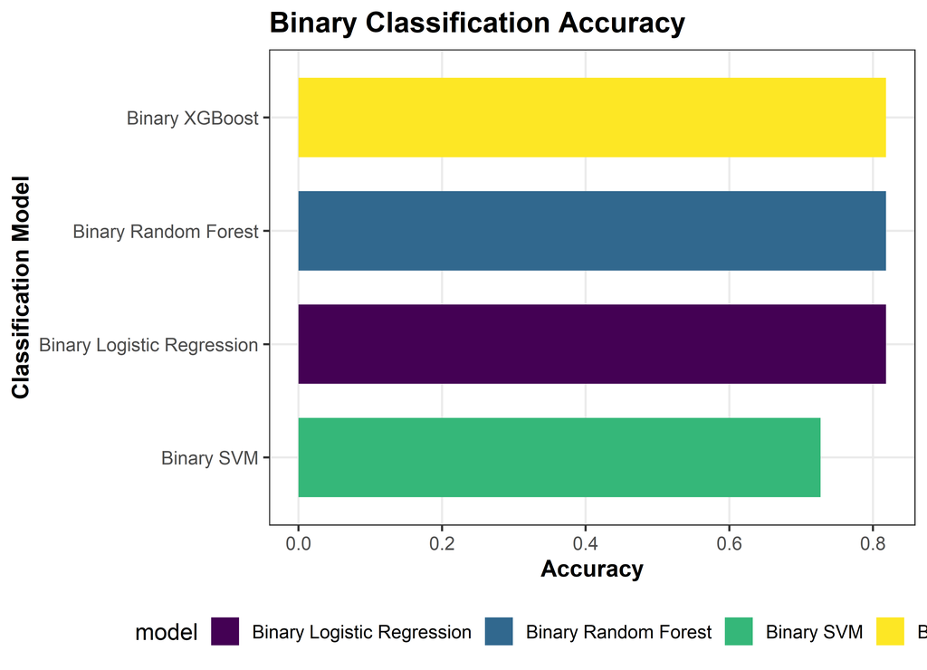

Comparison of overall accuracy among binary classification models.

```r
if("accuracy" %in% names(binary_results)){

p_accuracy <-

metric_plot(
binary_results,
"accuracy",
"Binary Classification Accuracy"
)+
labs(
x="Classification Model",
y="Accuracy"
)

p_accuracy

}else{

cat("**Accuracy metric was not available in the supplied Binary Summary worksheet.**")

}
```

**Interpretation**

The figure compares the overall classification accuracy achieved by each binary classification model. Higher accuracy indicates a greater proportion of correctly classified Healthy and CRC samples. Differences observed among models provide an initial indication of predictive performance; however, accuracy should always be interpreted alongside sensitivity, specificity, MCC, and AUC to account for potential class imbalance.

## 7.4 Area Under the ROC Curve (AUC)

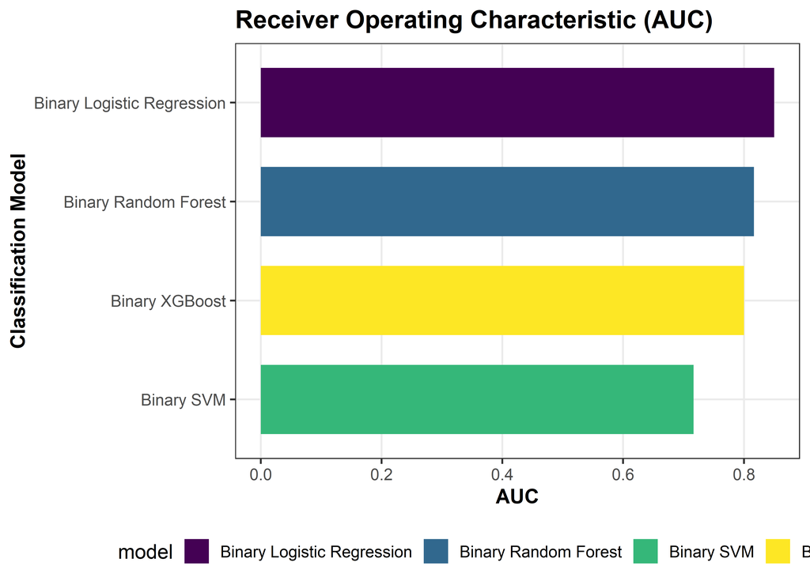

Comparison of AUC values for binary classification models.

```r
if("auc" %in% names(binary_results)){

metric_plot(
binary_results,
"auc",
"Receiver Operating Characteristic (AUC)"
)+
labs(
x="Classification Model",
y="AUC"
)

}else{

cat("**AUC was not available in the supplied Binary Summary worksheet.**")

}
```

**Interpretation**

The Area Under the ROC Curve (AUC) quantifies each model’s ability to discriminate between colorectal cancer and healthy control samples across all possible decision thresholds. Models with larger AUC values demonstrate stronger discriminatory capability and greater robustness to threshold selection.

## 7.5 Matthews Correlation Coefficient (MCC)

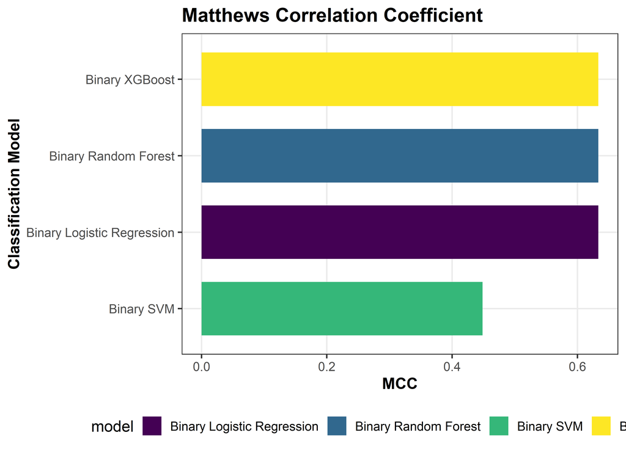

Comparison of Matthews Correlation Coefficient across binary models.

```r
if("mcc" %in% names(binary_results)){

metric_plot(
binary_results,
"mcc",
"Matthews Correlation Coefficient"
)+
labs(
x="Classification Model",
y="MCC"
)

}else{

cat("**MCC was not available in the supplied Binary Summary worksheet.**")

}
```

**Interpretation**

Matthews Correlation Coefficient is considered one of the most informative measures for binary classification because it incorporates all elements of the confusion matrix. Values approaching one indicate highly reliable classification performance, whereas values near zero indicate performance comparable to random prediction.

## 7.6 F1 Score

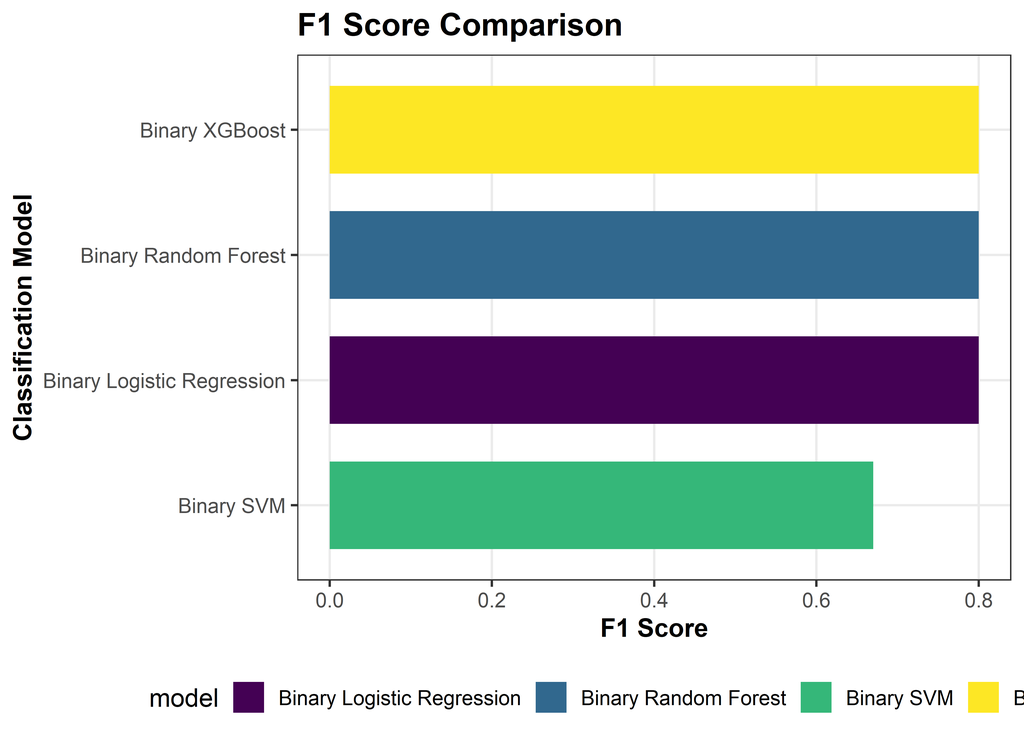

Comparison of F1 scores among binary classification models.

```r
if(any(names(binary_results)=="f1")){

metric_plot(
binary_results,
"f1",
"F1 Score Comparison"
)+
labs(
x="Classification Model",
y="F1 Score"
)

}else{

cat("**F1 Score was not available in the supplied Binary Summary worksheet.**")

}
```

**Interpretation**

The F1 score represents the harmonic mean of precision and recall, providing a balanced assessment of classification performance. Higher F1 values indicate improved capability for simultaneously minimizing false positive and false negative predictions.

## 7.7 Sensitivity Comparison

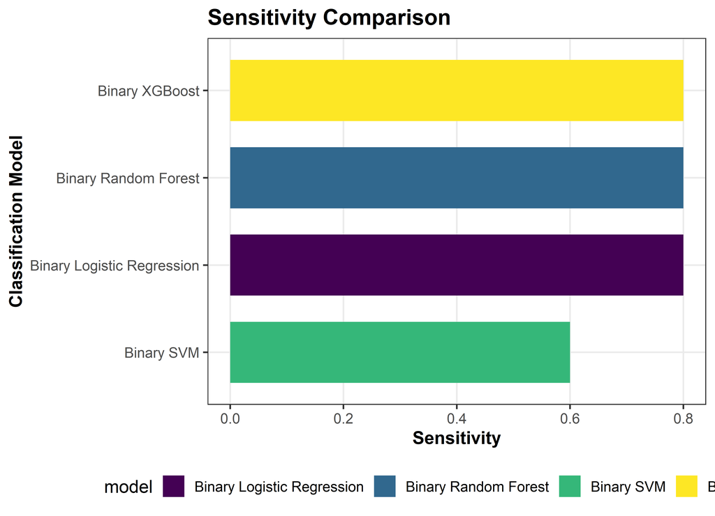

```r
if("sensitivity" %in% names(binary_results)){

metric_plot(
binary_results,
"sensitivity",
"Sensitivity Comparison"
)+
labs(
y="Sensitivity",
x="Classification Model"
)

}else{

cat("**Sensitivity metric not available.**")

}
```

**Interpretation**

Sensitivity reflects the proportion of colorectal cancer cases correctly identified by each classifier. High sensitivity is desirable for clinical screening applications because it reduces the likelihood of missing affected individuals.

## 7.8 Specificity Comparison

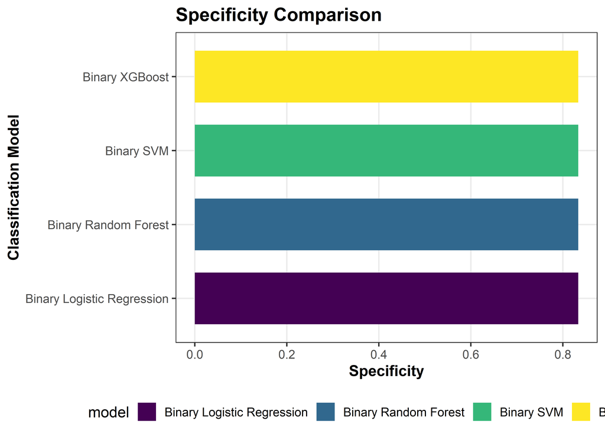

```r
if("specificity" %in% names(binary_results)){

metric_plot(
binary_results,
"specificity",
"Specificity Comparison"
)+
labs(
y="Specificity",
x="Classification Model"
)

}else{

cat("**Specificity metric not available.**")

}
```

**Interpretation**

Specificity measures the proportion of healthy individuals correctly classified as negative. Models with higher specificity reduce false positive diagnoses and therefore improve diagnostic precision.